# AprendizajeSupervisadoVoluntaria_EGT

Elena Garcia Torres

8 de enero de 2017

# INDICE

- 1. Enunciado
- 2. Filtrar el número de variables de entrada
- 3. Clasificador K-NN (ten fold cross-validation)
- 4. Clasificador C-SVM con kernel linear (ten fold cross-validation)
- 5. Clasificador C-SVM con kernel no lineal RBF (ten fold cross-validation)
- 6. Random Forest (ten fold cross-validation)
- 7. Proyectar Datos (PCA)
- 8. Comparar los diferentes modelos

## 1. Enunciado

Para los datos de Spam proporcionados en el moodle realizar las siguientes tareas: * Filtrar el número de variables de entrada. Identificar las palabras y símbolos que tienen mayor relevancia para la clasificación de Spam. * Para el clasificador k-NN, obtener el porcentaje de error y el índice kappa utilizando ten fold cross-validation. Determinar el valor de k óptimo. ¿ Qué ventajas e inconvenientes tiene este clasificador ? * Para el clasificador C-SVM con kernel lineal, obtener el porcentaje de error y el índice kappa utilizando ten fold cross-validation. Determinar el valor óptimo para el parámetro C. ¿ Qué podría comentar sobre la eficiencia computacional ? ¿ Y sobre la capacidad de generalización ? * Repetir el proceso anterior pero utilizando kernel no lineal RBF. Obtener los parámetros óptimos. ¿ Qué podría comentar ? * Para el clasificador Random Forest, obtener el porcentaje de error y el índice kappa utilizando ten fold cross-validation. Comentar el resultado y compararlo con los anteriores. * Proyectar los datos sobre un subespacio de dimensión menor utilizando PCA. ¿Cuántas componentes principales se deben calcular ? Comparar los resultados con los obtenidos en puntos anteriores. * Comparar los diferentes modelos y determinar cuáles serían los mejores en esta aplicación atendiendo a índice de error y eficiencia computacional.

## 2. Filtrar el número de variables de entrada

```
# Se comprueba si las librerias están isntaladas y si no lo están, se instalan
```

```r
currentDir <- getwd()

libs <- c("tm", "NLP", "kernlab", "caret", "ggplot2", "randomForest", "lattice")
  for (i in libs){
    print(i)
    if(!require(i, character.only = TRUE)) { install.packages(i); library(i) }
  }
```

```
## [1] "tm"
```

```
## [1] "NLP"
## [1] "kernlab"
```

```
## [1] "caret"
```

```
## [1] "ggplot2"
## [1] "randomForest"
```

```
## [1] "lattice"
```

```r
data(spam)

# se asigna seed para no tener valores aleatorios
cte.seed <- 1234

set.seed(cte.seed)
spam.traintest = rbinom(4601, size = 1, prob = 0.5)
table(spam.traintest)
```

```
## spam.traintest
##    0    1
## 2296 2305
```

```r
train.Spam = spam[spam.traintest == 1, ]
test.Spam = spam[spam.traintest == 0, ]

table(train.Spam$type)
```

```
##
## nonspam    spam
##    1405     900
```

```r
table(test.Spam$type)
```

```
##
## nonspam    spam
##    1383     913
```

```r
# Se comprueba si las dimensiones son congruentes
dim(train.Spam)
```

```
## [1] 2305   58
```

```r
dim(test.Spam)
```

```
## [1] 2296   58
```

```r
# Las proporciones se mantienen
prop.table( table(spam$type))
```

```
##
##   nonspam      spam
## 0.6059552 0.3940448
```

```r
prop.table( table(train.Spam$type))
```

```
##
##   nonspam      spam
## 0.6095445 0.3904555
```

```r
prop.table( table(test.Spam$type))
```

```
##
##   nonspam      spam
## 0.6023519 0.3976481
```

```r
#Identificar las palabras y símbolos que tienen mayor relevancia para la clasificación de Spam
```

## 3. Clasificador K-NN (ten fold cross-validation)

```r
    set.seed (cte.seed)

     # se usa la funcion "train" para construir el modelo K-NN
     Knn.spam <- train(type ~ ., data = train.Spam, method = "knn", tuneLength = 10, preProc = c("center", "scale"))

     Knn.spam
```

```
## k-Nearest Neighbors
##
## 2305 samples
##   57 predictor
##    2 classes: 'nonspam', 'spam'
##
## Pre-processing: centered (57), scaled (57)
## Resampling: Bootstrapped (25 reps)
## Summary of sample sizes: 2305, 2305, 2305, 2305, 2305, 2305, ...
## Resampling results across tuning parameters:
##
##   k   Accuracy   Kappa
##    5  0.8756117  0.7365372
##    7  0.8761215  0.7367925
##    9  0.8779876  0.7403640
##   11  0.8797522  0.7434887
##   13  0.8796356  0.7427898
##   15  0.8802308  0.7435507
##   17  0.8791350  0.7411664
##   19  0.8770666  0.7365040
##   21  0.8769927  0.7358962
##   23  0.8755585  0.7325637
##
## Accuracy was used to select the optimal model using  the largest value.
## The final value used for the model was k = 15.
```

```r
   # Variacion cruzada, trainControl
    ctrl <- trainControl(method = "repeatedcv", repeats = 5)
    Knn.spam.ctrl <- train(type ~ ., data = train.Spam, method = "knn", tuneLength = 10, trControl = ctrl, preProc = c("center", "scale"))
    Knn.spam.ctrl
```

```
## k-Nearest Neighbors
##
## 2305 samples
##   57 predictor
##    2 classes: 'nonspam', 'spam'
##
## Pre-processing: centered (57), scaled (57)
## Resampling: Cross-Validated (10 fold, repeated 5 times)
## Summary of sample sizes: 2074, 2074, 2074, 2074, 2075, 2075, ...
## Resampling results across tuning parameters:
##
##   k   Accuracy   Kappa
##    5  0.8966520  0.7809495
##    7  0.8937896  0.7737434
##    9  0.8932776  0.7721745
##   11  0.8920583  0.7694054
##   13  0.8917971  0.7686450
##   15  0.8905831  0.7654454
##   17  0.8887593  0.7612556
##   19  0.8868500  0.7569717
##   21  0.8843369  0.7516359
##   23  0.8843362  0.7516205
##
## Accuracy was used to select the optimal model using  the largest value.
## The final value used for the model was k = 5.
```

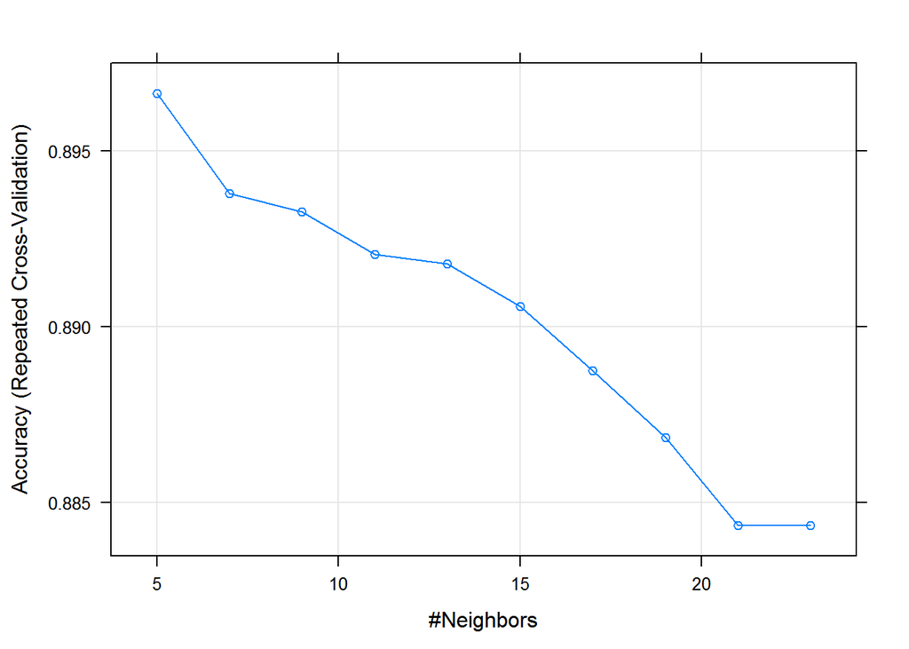

```r
    plot(Knn.spam.ctrl)
```

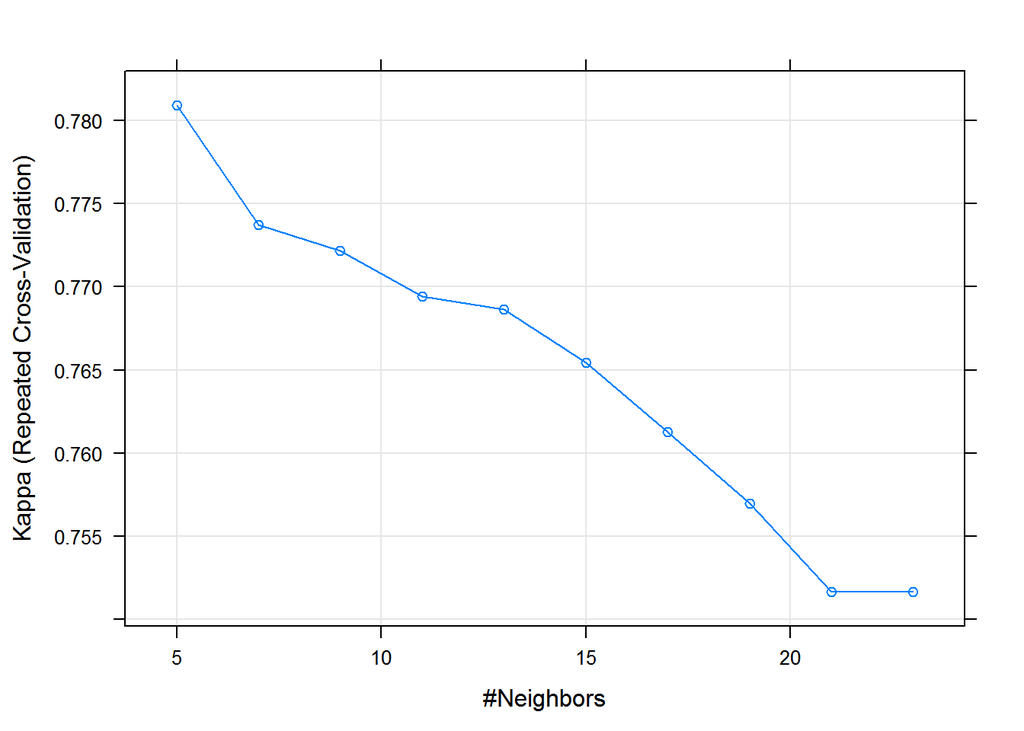

```r
    plot( Knn.spam.ctrl, metric="Kappa")
```

```r
    # Predicción
    Knn.spam.predict <- predict(Knn.spam.ctrl, newdata = test.Spam )

    # La eval del modelo se hace o por la matriz de confsion o tabla de contigencia y por la matrix RO
    confusionMatrix(Knn.spam.predict, test.Spam$type )
```

```
## Confusion Matrix and Statistics
##
##           Reference
## Prediction nonspam spam
##    nonspam    1279  137
##    spam        104  776
##
##                Accuracy : 0.895
##                  95% CI : (0.8818, 0.9073)
##     No Information Rate : 0.6024
##     P-Value [Acc > NIR] : < 2e-16
##
##                   Kappa : 0.7795
##  Mcnemar's Test P-Value : 0.03927
##
##             Sensitivity : 0.9248
##             Specificity : 0.8499
##          Pos Pred Value : 0.9032
##          Neg Pred Value : 0.8818
##              Prevalence : 0.6024
##          Detection Rate : 0.5571
##    Detection Prevalence : 0.6167
##       Balanced Accuracy : 0.8874
##
##        'Positive' Class : nonspam
##
```

## 4. Clasificador C-SVM con kernel lineal (ten fold cross-validation)

```r
set.seed(cte.seed)
 svm.spam.ctrl <- trainControl(method="repeatedcv", repeats=5)
 svm.spam.lineal <- train (type ~ ., data = train.Spam, method = "svmLinear", tuneLength = 10, trControl = svm.spam.ctrl)

 svm.spam.lineal
```

```
## Support Vector Machines with Linear Kernel
##
## 2305 samples
##   57 predictor
##    2 classes: 'nonspam', 'spam'
##
## No pre-processing
## Resampling: Cross-Validated (10 fold, repeated 5 times)
## Summary of sample sizes: 2075, 2074, 2075, 2075, 2074, 2074, ...
## Resampling results:
##
##   Accuracy   Kappa
##   0.9219108  0.8347474
##
## Tuning parameter 'C' was held constant at a value of 1
##
```

```r
 svm.spam.lineal.predict <- predict(svm.spam.lineal, test.Spam, "raw")

 confusionMatrix(svm.spam.lineal.predict, test.Spam$type)
```

```
## Confusion Matrix and Statistics
##
##           Reference
## Prediction nonspam spam
##    nonspam    1318  103
##    spam         65  810
##
##                Accuracy : 0.9268
##                  95% CI : (0.9154, 0.9371)
##     No Information Rate : 0.6024
##     P-Value [Acc > NIR] : < 2.2e-16
##
##                   Kappa : 0.8462
##  Mcnemar's Test P-Value : 0.004309
##
##             Sensitivity : 0.9530
##             Specificity : 0.8872
##          Pos Pred Value : 0.9275
##          Neg Pred Value : 0.9257
##              Prevalence : 0.6024
##          Detection Rate : 0.5740
##    Detection Prevalence : 0.6189
##       Balanced Accuracy : 0.9201
##
##        'Positive' Class : nonspam
##
```

## 5. Clasificador C-SVM con kernel no lineal RBF (ten fold cross-validation)

```r
 set.seed(cte.seed)
 svmR.spam.ctrl <- trainControl(method="repeatedcv", repeats=5)
 svmR.spam.radial <- train (type ~ ., data = train.Spam, method = "svmRadial", tuneLength = 10, trControl = svmR.spam.ctrl)
 svmR.spam.radial
```

```
## Support Vector Machines with Radial Basis Function Kernel
##
## 2305 samples
##   57 predictor
##    2 classes: 'nonspam', 'spam'
##
## No pre-processing
## Resampling: Cross-Validated (10 fold, repeated 5 times)
## Summary of sample sizes: 2075, 2074, 2075, 2075, 2074, 2074, ...
## Resampling results across tuning parameters:
##
##   C       Accuracy   Kappa
##     0.25  0.9066403  0.7992873
##     0.50  0.9172291  0.8232745
##     1.00  0.9256458  0.8419957
##     2.00  0.9251233  0.8410188
##     4.00  0.9246896  0.8403207
##     8.00  0.9229554  0.8366363
##    16.00  0.9226945  0.8362892
##    32.00  0.9194850  0.8293680
##    64.00  0.9192249  0.8288815
##   128.00  0.9135818  0.8172027
##
## Tuning parameter 'sigma' was held constant at a value of 0.03004475
## Accuracy was used to select the optimal model using  the largest value.
## The final values used for the model were sigma = 0.03004475 and C = 1.
```

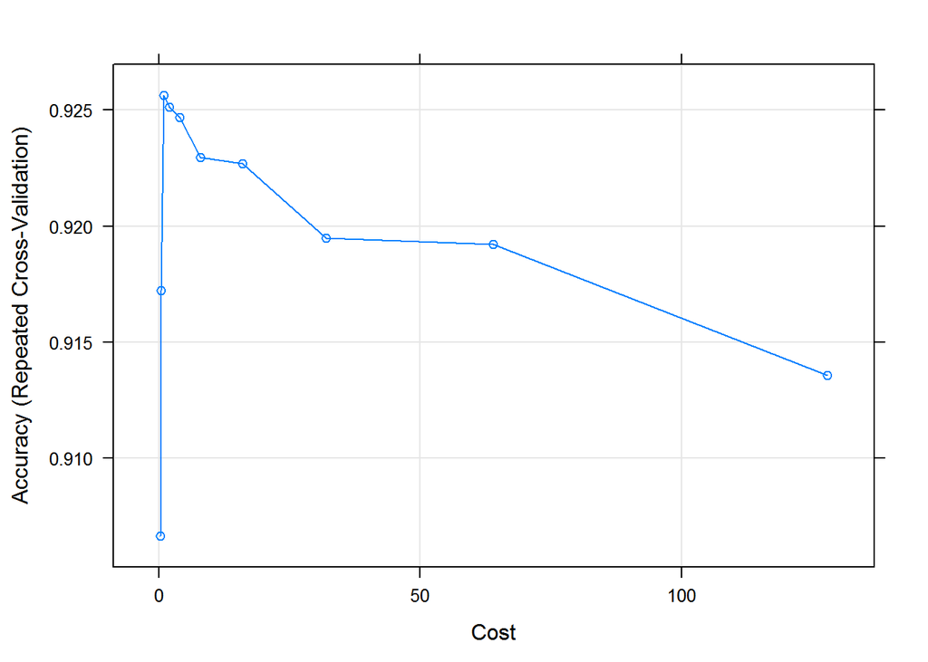

```r
 plot (svmR.spam.radial)
```

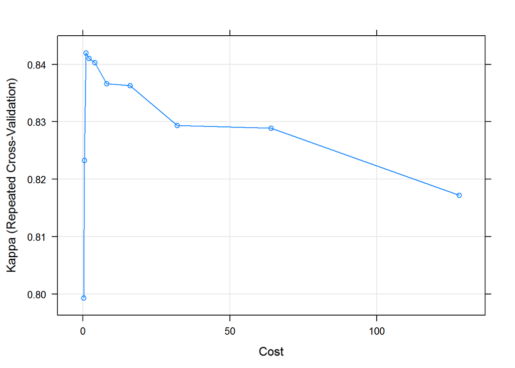

```r
 plot (svmR.spam.radial, metric="Kappa")
```

```r
 radial.predict <- predict(svmR.spam.radial, test.Spam, "raw")
 confusionMatrix(radial.predict, test.Spam$type)
```

```
## Confusion Matrix and Statistics
##
##           Reference
## Prediction nonspam spam
##    nonspam    1316  113
##    spam         67  800
##
##                Accuracy : 0.9216
##                  95% CI : (0.9098, 0.9323)
##     No Information Rate : 0.6024
##     P-Value [Acc > NIR] : < 2.2e-16
##
##                   Kappa : 0.8349
##  Mcnemar's Test P-Value : 0.0007962
##
##             Sensitivity : 0.9516
##             Specificity : 0.8762
##          Pos Pred Value : 0.9209
##          Neg Pred Value : 0.9227
##              Prevalence : 0.6024
##          Detection Rate : 0.5732
##    Detection Prevalence : 0.6224
##       Balanced Accuracy : 0.9139
##
##        'Positive' Class : nonspam
##
```

## 6. Random Forest (ten fold cross-validation)

```r
 set.seed(cte.seed)
 rf.spam.ctrl <- trainControl(method="repeatedcv", repeats=5)
 rf.spam <- train (type ~ ., data = train.Spam, method = "rf", tuneLength = 10, trControl = rf.spam.ctrl)
 rf.spam
```

```
## Random Forest
##
## 2305 samples
##   57 predictor
##    2 classes: 'nonspam', 'spam'
##
## No pre-processing
## Resampling: Cross-Validated (10 fold, repeated 5 times)
## Summary of sample sizes: 2075, 2074, 2075, 2075, 2074, 2074, ...
## Resampling results across tuning parameters:
##
##   mtry  Accuracy   Kappa
##    2    0.9367514  0.8652074
##    8    0.9455133  0.8844431
##   14    0.9426516  0.8784888
##   20    0.9408304  0.8747158
##   26    0.9393518  0.8715390
##   32    0.9390070  0.8707457
##   38    0.9386588  0.8700694
##   44    0.9394414  0.8716820
##   50    0.9384845  0.8696210
##   57    0.9374444  0.8673816
##
## Accuracy was used to select the optimal model using  the largest value.
## The final value used for the model was mtry = 8.
```

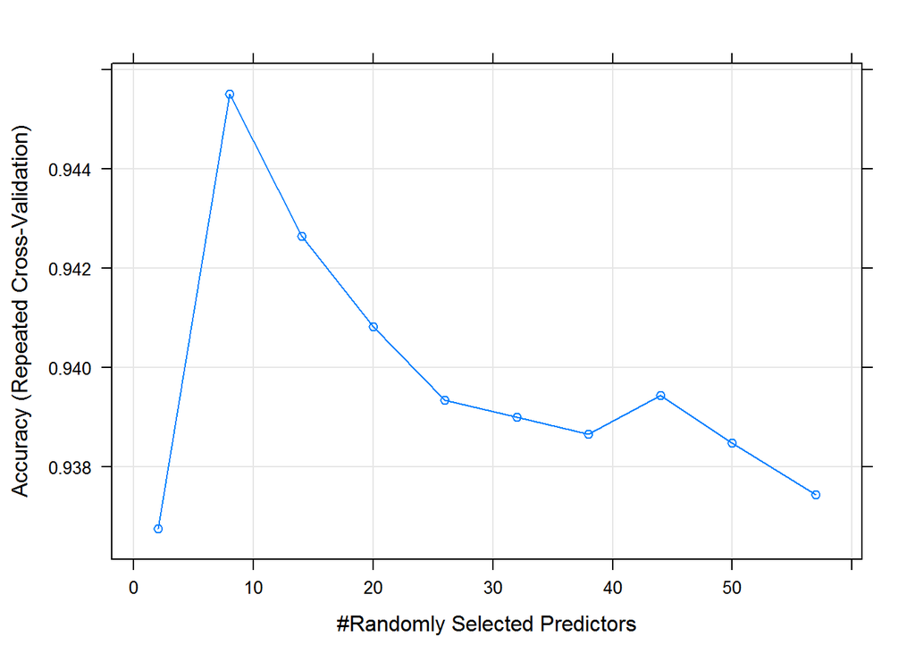

```r
 plot (rf.spam)
```

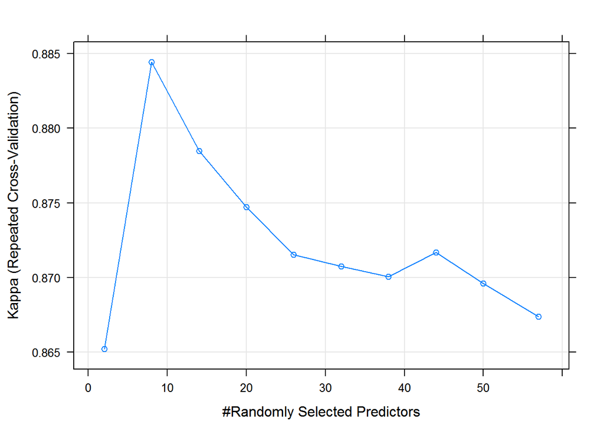

```r
 plot (rf.spam, metric="Kappa")
```

```r
 predictions.randomforest <- predict(rf.spam, test.Spam, "raw")
confusionMatrix(predictions.randomforest, test.Spam$type)
```

```
## Confusion Matrix and Statistics
##
##           Reference
## Prediction nonspam spam
##    nonspam    1338   62
##    spam         45  851
##
##                Accuracy : 0.9534
##                  95% CI : (0.944, 0.9617)
##     No Information Rate : 0.6024
##     P-Value [Acc > NIR] : <2e-16
##
##                   Kappa : 0.9024
##  Mcnemar's Test P-Value : 0.1219
##
##             Sensitivity : 0.9675
##             Specificity : 0.9321
##          Pos Pred Value : 0.9557
##          Neg Pred Value : 0.9498
##              Prevalence : 0.6024
##          Detection Rate : 0.5828
##    Detection Prevalence : 0.6098
##       Balanced Accuracy : 0.9498
##
##        'Positive' Class : nonspam
##
```

## 7. Proyectar Datos (PCA)

```r
set.seed (cte.seed)
M <- abs(cor(train.Spam[,-58]))

diag(M) <- 0

#selección alta correlación
which(M > 0.8, arr.ind=TRUE)
```

```
##        row col
## num857  32  31
## num415  34  31
## telnet  31  32
## num415  34  32
## direct  40  32
## telnet  31  34
## num857  32  34
## direct  40  34
## num857  32  40
## num415  34  40
```

```r
names(spam)[c(34,32)]
```

```
## [1] "num415" "num857"
```

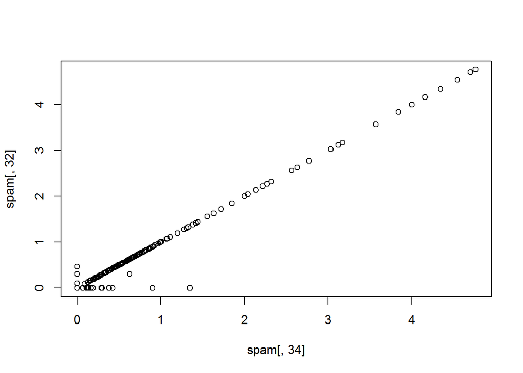

```r
plot(spam[,34], spam[,32])
```

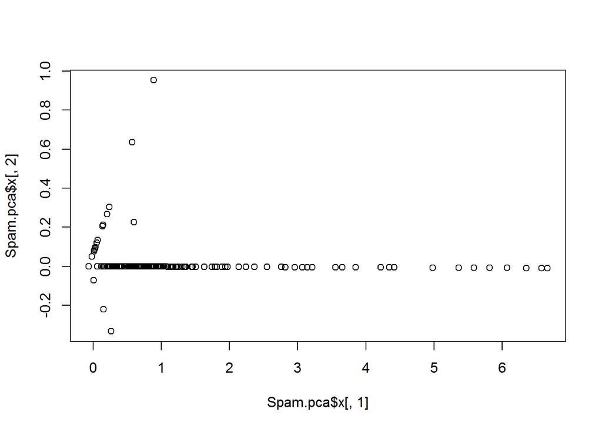

```r
# PCA
Spam.Reducido <- spam[,c(34,32)]
Spam.pca <- prcomp(Spam.Reducido)
plot(Spam.pca$x[,1], Spam.pca$x[,2])
```

```r
Spam.pca$rotation
```

```
##              PC1        PC2
## num415 0.7080625  0.7061498
## num857 0.7061498 -0.7080625
```

## 8. Comparar los diferentes modelos

```r
models <- list(Knn.spam.ctrl, svm.spam.lineal, svmR.spam.radial, rf.spam)

cv.samples <- resamples(models)
summary( cv.samples)
```

```
##
## Call:
## summary.resamples(object = cv.samples)
##
## Models: Model1, Model2, Model3, Model4
## Number of resamples: 50
##
## Accuracy
##          Min. 1st Qu. Median   Mean 3rd Qu.   Max. NA's
## Model1 0.8478  0.8842 0.9000 0.8967  0.9077 0.9437    0
## Model2 0.8788  0.9087 0.9221 0.9219  0.9350 0.9524    0
## Model3 0.8745  0.9174 0.9241 0.9256  0.9351 0.9652    0
## Model4 0.9174  0.9348 0.9436 0.9455  0.9565 0.9740    0
##
## Kappa
##          Min. 1st Qu. Median   Mean 3rd Qu.   Max. NA's
## Model1 0.6786  0.7562 0.7867 0.7809  0.8070 0.8800    0
## Model2 0.7399  0.8066 0.8352 0.8347  0.8633 0.8998    0
## Model3 0.7301  0.8239 0.8391 0.8420  0.8639 0.9264    0
## Model4 0.8246  0.8613 0.8802 0.8844  0.9082 0.9450    0
```

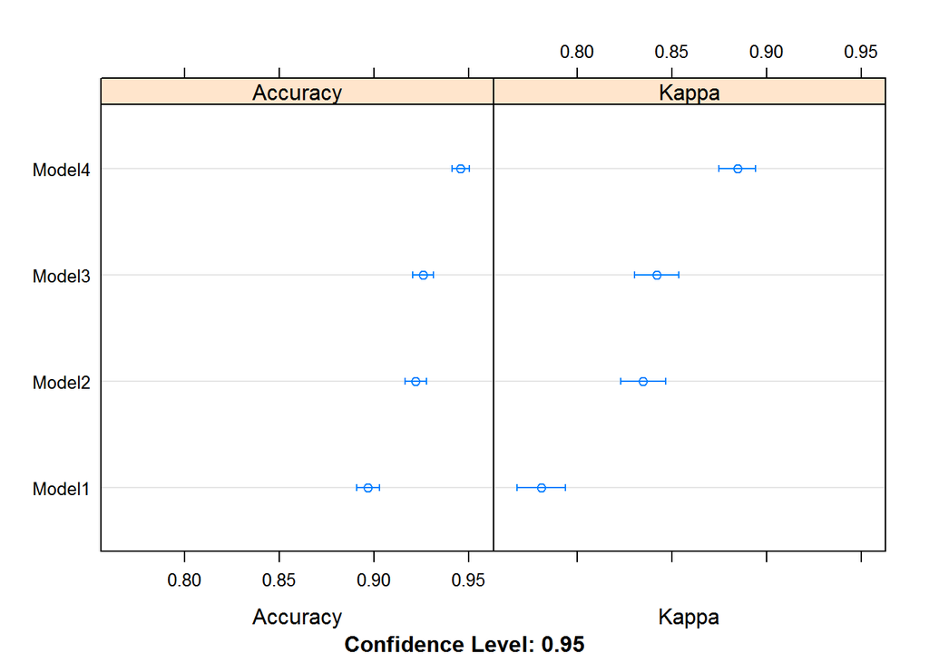

```r
# Visualización resultados comparación

dotplot( cv.samples)
```